# Lab 8

## RF preprocessing

```r
# specify recipe for model preprocessing
covtype_recipe <- recipe(cover_type ~ ., data = covtype_df) %>%
  step_dummy(all_nominal_predictors(), -all_outcomes()) %>%
  step_normalize(all_numeric_predictors()) %>%
  prep() # prep recipe
```

## Linear SVM preprocessing

```r
# specify recipe for model preprocessing
svm_recipe <- recipe(cover_type ~ ., data = covtype_df) %>%
  step_dummy(all_nominal_predictors()) %>%
  step_center(all_numeric_predictors()) %>% # center to mean of 0
  step_scale(all_numeric_predictors()) # scale to sd of 1
```

3. Create the folds for cross-validation.

```r
# initial split of data (default 70/30)
covtype_split <- initial_split(covtype_df, strata = cover_type, prop = 0.7)
covtype_test <- testing(covtype_split)
covtype_train <- training(covtype_split)
```

```r
# create 10 folds of the training dataset for CV
cv_folds <- covtype_train %>% vfold_cv(v = 10)
```

4. Tune the models. Choose appropriate parameters and grids. If the computational costs of tuning given your strategy are prohibitive, how might you work around this?

If the computational costs of tuning are prohibitive, my first work around would be to remove the soil type columns that are least common in the data. Another work around could be to remove the numeric features with the lowest variance, as these would be the features that are most likely to be the least important for predicting the class of the outcome variable, though this is not necessarily true all the time.

## Random forest model tuning

```r
# specify RF model
rf_spec <- rand_forest(trees = 500, mtry = tune(), min_n = tune()) %>%
  set_engine("ranger") %>%
  set_mode("classification")

# create a tuning grid
rf_grid <- grid_latin_hypercube(
  mtry(range = c(2, 4)),
  min_n(c(1, 10)),
  size = 20
)

# create workflow
wf_rf <- workflow() %>%
  add_recipe(covtype_recipe) %>%
  add_model(rf_spec)
```

```r
# tune the model
rf_tune_res <- tune_grid(
  wf_rf,
  resamples = cv_folds,
  grid = rf_grid
)
```

```r
# select optimal parameters
best_rf_params <- select_best(rf_tune_res, "accuracy")

# finalize the model with optimal parameters
final_rf <- finalize_model(rf_spec, best_rf_params)

# create a new workflow with finalized model
final_rf_workflow <- workflow() %>%
  add_recipe(covtype_recipe) %>%
  add_model(final_rf)

# fit final workflow to the training data
final_rf_fit <- final_rf_workflow %>%
  fit(data = covtype_train)
```

## Linear SVM model tuning

```r
# create linear SVM model specification
svm_linear_spec <- svm_poly(degree = 1, cost = tune()) %>%
  set_mode("classification") %>%
  set_engine("kernlab")

# create workflow
svm_linear_wf <- workflow() %>%
  add_model(svm_linear_spec %>%
            set_args(cost = tune())) %>%
  add_formula(cover_type ~ .)

# create grid of cost values to tune with
param_grid <- grid_regular(cost(), levels = 10)
```

```r
# tune for cost
tune_results <- tune_grid(svm_linear_wf,
                          resamples = cv_folds,
                          grid = param_grid)
```

```r
# select optimal cost
best_cost <- select_best(tune_results, metric = "accuracy")

# create finalized workflow with optimal cost
svm_linear_final <- finalize_workflow(svm_linear_wf, best_cost)

# fit finalized workflow to the training data
svm_linear_fit <- svm_linear_final %>% fit(covtype_train)
```

```
## maximum number of iterations reached 0.002013386 0.001992932
```

## Nonlinear SVM model tuning

```r
# create non-linear SVM model specification using radial basis function
svm_rbf_spec <- svm_rbf() %>%  # use radial basis
  set_mode("classification") %>%
  set_engine("kernlab")
```

```r
# fit the specified model to the training data
svm_rbf_fit <- svm_rbf_spec %>%
  fit(cover_type ~ ., data = covtype_train)
```

5. Conduct final predictions for both models and compare their prediction performances and computation costs from part 4.

## Random forest model predictions

```r
# predict testing data
test_predict_rf <- predict(final_rf_fit, covtype_test) %>%
  bind_cols(covtype_test) %>%
  mutate(cover_type = as.factor(cover_type))

# calculate accuracy
accuracy(test_predict_rf, truth = cover_type, estimate = .pred_class)
```

```
## # A tibble: 1 × 3
##   .metric  .estimator .estimate
##   <chr>    <chr>          <dbl>
## 1 accuracy multiclass     0.786
```

```r
# calculate sensitivity
sensitivity(test_predict_rf, truth = cover_type, estimate = .pred_class)
```

```
## # A tibble: 1 × 3
##   .metric     .estimator .estimate
##   <chr>       <chr>          <dbl>
## 1 sensitivity macro          0.476
```

```r
# calculate specificity
specificity(test_predict_rf, truth = cover_type, estimate = .pred_class)
```

```
## # A tibble: 1 × 3
##   .metric     .estimator .estimate
##   <chr>       <chr>          <dbl>
## 1 specificity macro          0.948
```

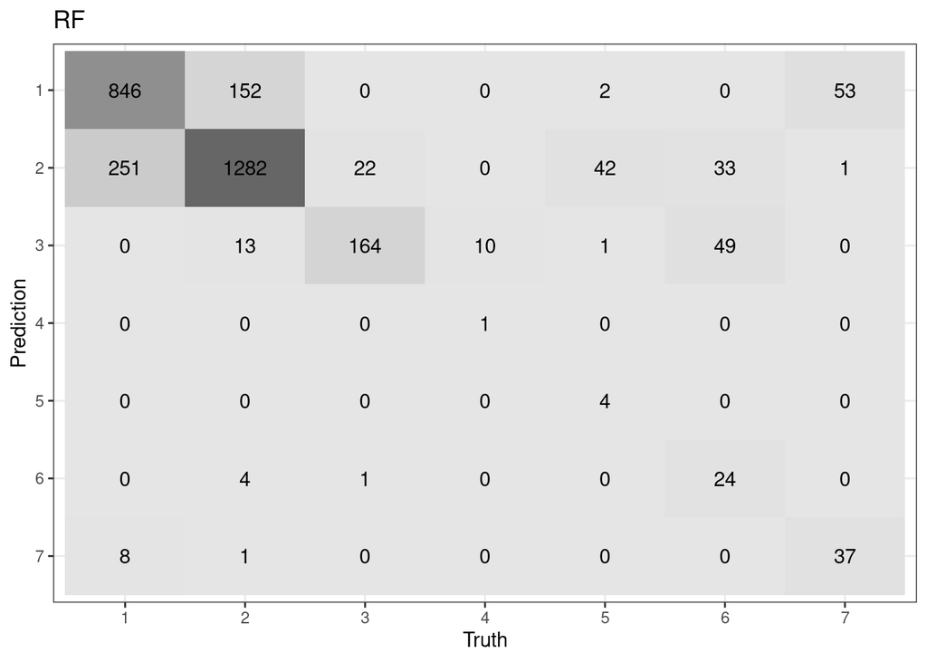

```r
# make confusion matrix for predictions made on testing data
test_predict_rf %>%
  conf_mat(truth = cover_type, estimate = .pred_class) %>%
  autoplot(type = "heatmap") +
  ggtitle("RF") +
  theme_bw() +
  theme(legend.position = "none")
```

## Linear SVM model predictions

```r
# predict testing data and calculate accuracy
augment(svm_linear_fit, new_data = covtype_test) %>%
  accuracy(truth = cover_type, estimate = .pred_class)
```

```
## # A tibble: 1 × 3
##   .metric  .estimator .estimate
##   <chr>    <chr>          <dbl>
## 1 accuracy multiclass     0.742
```

```r
# predict testing data and calculate sensitivity
augment(svm_linear_fit, new_data = covtype_test) %>%
  sensitivity(truth = cover_type, estimate = .pred_class)
```

```
## # A tibble: 1 × 3
##   .metric     .estimator .estimate
##   <chr>       <chr>          <dbl>
## 1 sensitivity macro          0.495
```

```r
# predict testing data and calculate specificity
augment(svm_linear_fit, new_data = covtype_test) %>%
  specificity(truth = cover_type, estimate = .pred_class)
```

```
## # A tibble: 1 × 3
##   .metric     .estimator .estimate
##   <chr>       <chr>          <dbl>
## 1 specificity macro          0.938
```

```r
# predict testing data and make confusion matrix
augment(svm_linear_fit, new_data = covtype_test) %>%
  conf_mat(truth = cover_type, estimate = .pred_class)
```

```
##           Truth
## Prediction    1    2    3    4    5    6    7
##          1  795  227    0    0    0    0   40
##          2  286 1207   26    0   48   33    0
##          3    0   15  153    5    1   55    0
##          4    0    0    1    4    0    0    0
##          5    0    0    0    0    0    0    0
##          6    1    2    7    2    0   18    0
##          7   23    1    0    0    0    0   51
```

## Non-linear SVM model predictions

```r
# predict testing data and calculate accuracy
augment(svm_rbf_fit, new_data = covtype_test) %>%
  accuracy(truth = cover_type, estimate = .pred_class)
```

```
## # A tibble: 1 × 3
##   .metric  .estimator .estimate
##   <chr>    <chr>          <dbl>
## 1 accuracy multiclass     0.749
```

```r
# predict testing data and calculate sensitivity
augment(svm_rbf_fit, new_data = covtype_test) %>%
  sensitivity(truth = cover_type, estimate = .pred_class)
```

```
## # A tibble: 1 × 3
##   .metric     .estimator .estimate
##   <chr>       <chr>          <dbl>
## 1 sensitivity macro          0.423
```

```r
# predict testing data and calculate specificity
augment(svm_rbf_fit, new_data = covtype_test) %>%
  specificity(truth = cover_type, estimate = .pred_class)
```

```
## # A tibble: 1 × 3
##   .metric     .estimator .estimate
##   <chr>       <chr>          <dbl>
## 1 specificity macro          0.940
```

```r
# predict testing data and make confusion matrix
augment(svm_rbf_fit, new_data = covtype_test) %>%
  conf_mat(truth = cover_type, estimate = .pred_class)
```

```
##           Truth
## Prediction    1    2    3    4    5    6    7
##          1  806  189    0    0    0    0   48
##          2  280 1234   25    0   46   40    2
##          3    0   27  158    9    2   59    0
##          4    0    0    0    0    0    0    0
##          5    0    0    0    0    1    0    0
##          6    0    0    4    2    0    7    0
##          7   19    2    0    0    0    0   41
```

- Which type of model do you think is better for this task?

- Why do you speculate this is the case?